# Chapter 6 Homework

AP

1/30/2022

## Question 1

My friend’s reasoning does not make sense, because a causal relationship doesn’t have to mean that X ALWAYS causes Y, it just means that X is one part of the data generating process that creates Y. Being tall is one part of the DGP that creates earning more than $100k a year, but it can be outweighed by other parts of the DGP (maybe the tall people my friend knows all happen to be lazy and the short people happen to be highly motivated, for example).

## Question 2

CoinFlip and TerryInRoom have a direct effect on Money; Terry’sMood has an indirect effect on Money through TerryInRoom.

## Question 3

Direct effects: HarryPotterAsKid $\rightarrow$ ReadingAsAdult

Relevant indirect effects: HarryPotterAsKid $\rightarrow$ ReadOtherRowlingBooks $\rightarrow$ ReadingAsAdult

Alternative explanation: LikesReading $\rightarrow$ (HarryPotterAsKid AND ReadingAsAdult)

## Question 4

It’s important to include some unobserved/latent variables if they are key parts of the DGP. They also help make alternative explanations clearer on our diagram.

LikesReading is something that we know probably affects both HarryPotterAsKid and ReadingAsAdult, but it would be hard to accurately measure how much an adult liked reading as a kid, so we put it in as a latent variable.

## Question 5

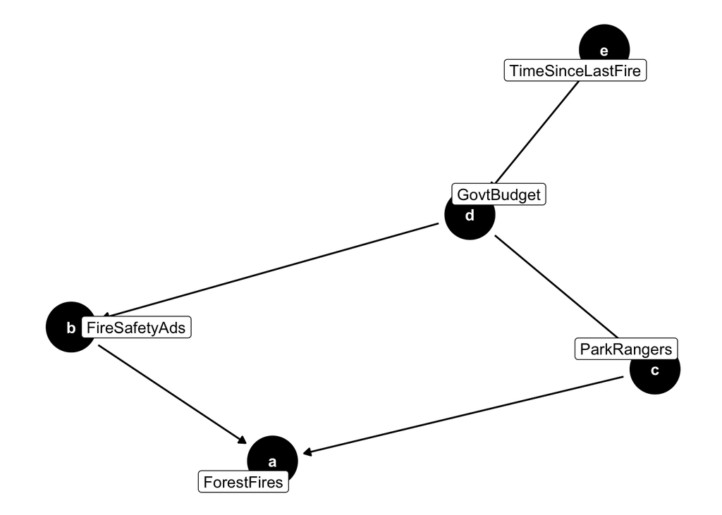

One variable I think should be included is Region, because some regions are more prone to forest fires and also would have an easier time raising money to allocate to the Parks department.

## Question 6

Research question: Does having health insurance improve your self-rated health?

Cause of interest: Health insurance coverage; Outcome of interest: Self-rated health

Other variables that are in play: Utilization of health care services, chronic illness, income, employment

Possible latent variables: restrictiveness of state health insurance policy

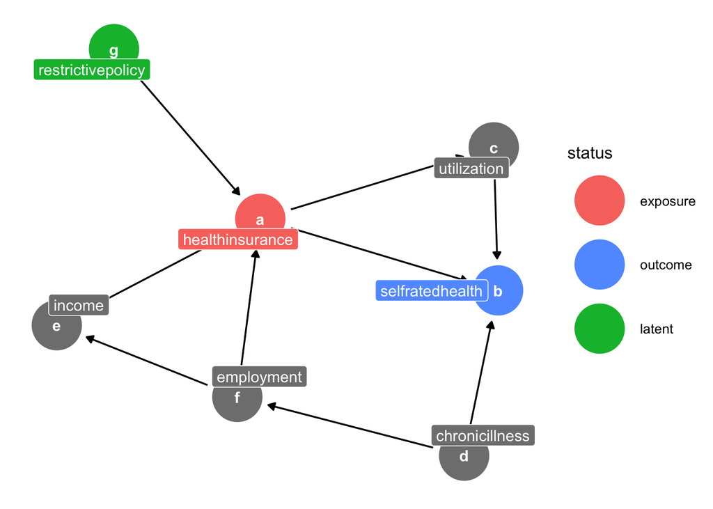

## Question 7

Variables: free shipping, buying habits, income, time of year, stinginess, trust in the Internet

It may not be feasible to measure stinginess or trust in the Internet, but the others should be fine.

## Question 8

X causes Y when, if you were able to intervene and change the value of X, Y would also change as a result.

Causation is interesting and important because a lot of questions that impact people’s lives are causal in nature. For example, if we want policymakers to institute free health insurance, we can’t just say “health insurance is somehow related to population health,” we want to be able to say “health insurance CAUSES better population health.” Causal explanations are more readily applicable to the real world, and make for more directly beneficial research.

## Question 9

D